# RMSE Anova Analysis

Below are my adventures into ANOVA analysis of RMSE derived from user studies where the user had to match a tempo fluctuating template. During the study the participant had to listen to an excerpt of music with varying tempo. She then had to match the excerpt using three different methods. Figure below shows the resulting Inter Onset Intervals (IOIs) of three different methods. The solid black line depicts IOIs from the template. Rest of the lines depict IOIs derived from user playing with three different methods

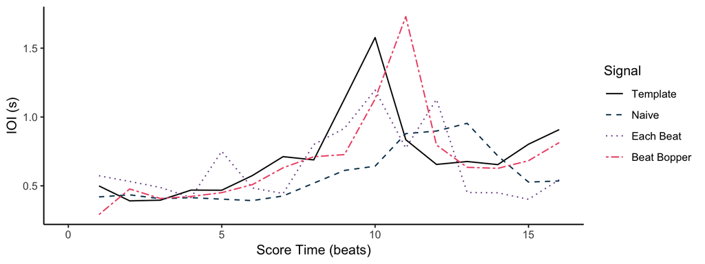

I want to calculate which is the best method accross all of the templates for all of the users. I have run into multiple problems. Mainly, do I normalise data from different excerpts? Different excerpts have different lengths, therefore I feel that comparing RMSEs from all of the excerpts in a single ANOVA is unfair. I will try to demonstrate steps taken here.

$RMSError = \sqrt(\frac{\sum_{i=1}^{n}(\hat{y}_i-y_i)^2}{n})$ where $y$ is the template and $\hat{y}$ is the signal which we want to get RMSE for. Once the data from the study has been collected. I wonder if need to normalize it.

## Non-Normalised

Below are bar boxplots for non-noramlised data for all three excerpts.

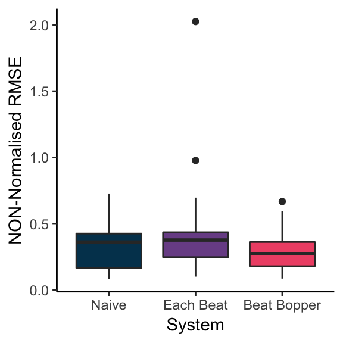

In general data is stored like this. First column is the excerpt, second is the RMSE, and the third is the system under test.

```
##   excerpt      rmse systems
## 1      e1 0.4277404   Naive
## 2      e1 0.3632408   Naive
## 3      e1 0.3901020   Naive
## 4      e1 0.4338885   Naive
## 5      e1 0.2754448   Naive
## 6      e1 0.4223357   Naive
```

When we conduct anova we get a significant difference of $p<0.05$

```
##              Df Sum Sq Mean Sq F value Pr(>F)
## systems       2  0.407 0.20345   6.679 0.0015 **
## Residuals   240  7.311 0.03046
## ---
## Signif. codes:  0 '***' 0.001 '**' 0.01 '*' 0.05 '.' 0.1 ' ' 1
```

```
##   Tukey multiple comparisons of means
##     95% family-wise confidence level
##
## Fit: aov(formula = rmse ~ systems, data = my_data)
##
## $systems
##                              diff          lwr         upr     p adj
## Each Beat-Naive        0.05729987 -0.007378294  0.12197804 0.0941811
## Beat Bopper-Naive     -0.04257284 -0.107251004  0.02210533 0.2685349
## Beat Bopper-Each Beat -0.09987271 -0.164550875 -0.03519454 0.0009649
```

### Testing ANOVA assumptions

#### Homogeneity of variances

Below we see that there are few outliers

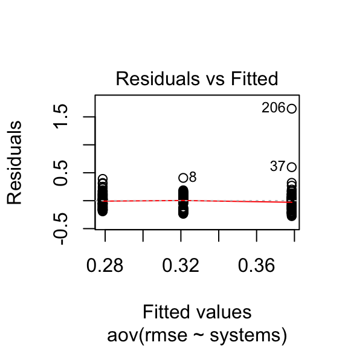

We can also use Levene’s test, which is less sensitive to outliers. We can see below that p-value is not significant, therefoer we can assume that there is no evidence to suggest that variances in our groups are significally different.

```
## Levene's Test for Homogeneity of Variance (center = median)
##        Df F value Pr(>F)
## group   2  0.8431 0.4316
##       240
```

#### Normality assumptions

Plot belw shows that data is not normally distributed

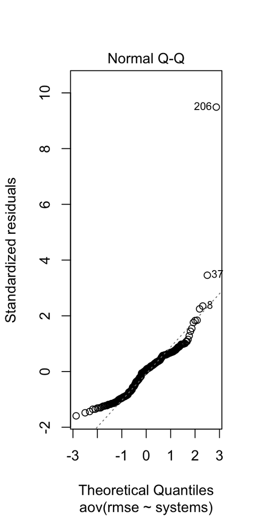

This is confirmed by Shapiro-Wilk test

```
##
##  Shapiro-Wilk normality test
##
## data:  aov_residuals
## W = 0.77044, p-value < 2.2e-16
```